# 19_08_2024_S_van_Mesdag_Warton_and_Hodbarrow_CCAs

Savanna van Mesdag

2024-08-19

##The following is written by Savanna van Mesdag, going through the relevant coding and analyses for CCAs and ANOSIMs for the plant and substrate data for the Warton slag bank and the RSPB Hodbarrow Nature Reserve.

#setwd#

#To run the following code to carry out the analyses, the following packages must be installed#

```r
install.packages("vegan", repos = "https://github.com/vegandevs/vegan")
```

```r
install.packages("ggplot2", repos = "https://github.com/tidyverse/ggplot2")
```

#Once installed, then need to load these r packages…

```r
library(vegan)
```

```r
library(ggplot2)
```

#Loading the data files…

##Carnforth Data

```r
urlfile11 <- 'https://raw.githubusercontent.com/Savannankvm/Canonical-correspondence-analyses-Warton-and-Hodbarrow/PhD-files/CarnforthPlantSpecies.csv'

CarnforthPS <- read.csv(urlfile11, header = TRUE, colClasses = c("numeric"))

urlfile12 <- 'https://raw.githubusercontent.com/Savannankvm/Canonical-correspondence-analyses-Warton-and-Hodbarrow/PhD-files/CARNFORTH_PLANT_CHEMISTRY_MG_KG.csv'

CarnforthPC <-read.csv(urlfile12, header = TRUE, colClasses = c("numeric"))

head(CarnforthPS)
```

```
##   Agrostis.spp. Agrostis.canina Alchemilla.mollis Alopercus.pratensis
## 1             0               0                 0                   0
## 2             0               0                 0                   0
## 3             0               0                 0                   0
## 4             0               0                 0                   0
## 5             0               0                 0                   0
## 6             0               0                 0                  27
##   Angelica.sylvestris Anthoxanthum.odoratum Anthyllis.vulneraria
## 1                   0                     0                    0
## 2                   0                     0                    0
## 3                   0                     0                    0
## 4                   0                     0                    0
## 5                   0                     0                    0
## 6                   0                     0                    0
##   Aphanes.arvensis Arrhenatherum.elatius Atrichum.undulatum Avenula.pratensis
```

[output cut: 251 more lines]

```r
head(CarnforthPC)
```

```
##   pH_level     SiO2    Al2O3      Fe2O3      CaO      MgO     Na2O       K2O
## 1    9.008 182299.6 47632.53 153873.611 164378.9 6030.359 2967.428 10791.921
## 2   10.175 159862.7 52131.16   7903.508 262291.5 8924.931 2151.385  3486.621
## 3   10.589 170613.7 44139.48  20283.340 204401.6 8140.985 2299.756  5561.990
## 4    9.516 181832.2 35936.10   7833.566 200828.1 8080.681 2596.499  4648.828
## 5   10.133 142567.7 43927.78   4826.036 250141.8 9769.182 1186.971  2407.429
## 6    8.790 200997.0 31755.02 181850.631 121497.4 6030.359 3709.284 13282.364
##       Cr2O3     TiO2      MnO     P2O5      SrO       BaO   LOI   Ag As  B   Be
## 1 342.10121 3596.057 5421.202 999.8709 287.5021 1791.3027 22.86 0.00  0  0  0.0
## 2  27.36810 4495.072 1858.698 399.9484 338.2378 1433.0422 13.90 0.15  3 50 12.8
## 3  20.52607 2637.109 1936.144 599.9225 253.6784  716.5211 19.00 1.30 11 60  8.4
## 4  41.05215 2457.306 1781.252 499.9354 253.6784  985.2165 20.70 0.30  7 40  8.6
## 5  13.68405 3356.320  929.349 599.9225 253.6784  716.5211 22.20 0.30  3 40 11.4
## 6  68.42024 1798.029 2323.372 999.8709 211.3986  806.0862 20.61 0.00  0  0  0.0
##    Bi   Cd Co Cu Ga  Hg La Li  Mo Ni  Pb     S   Sb Sc Th Tl  U   V W   Zn
```

[output cut: 41 more lines]

```r
rowSums(CarnforthPS)
```

```
## [1] 795 568 552 322 517 206 319 343
```

#Now for some ANOSIMs…

#anoCSiO2 <- anosim(CarnforthPS, CarnforthPC$SiO2, distance = “bray”, permutations = 9999)

#When this ANOSIM is run, the error message: “there should be replicates within groups” #comes up. From now on, only variables that were tested successfully will be included.

```r
anoCMgO <- anosim(CarnforthPS, CarnforthPC$MgO, distance = "bray", permutations = 9999)

anoCMgO
```

```
##
## Call:
## anosim(x = CarnforthPS, grouping = CarnforthPC$MgO, permutations = 9999,      distance = "bray")
## Dissimilarity: bray
##
## ANOSIM statistic R: 0.1852
##       Significance: 0.4336
##
## Permutation: free
## Number of permutations: 9999
```

```r
anoCCr2O3 <- anosim(CarnforthPS, CarnforthPC$Cr2O3, distance = "bray", permutations = 9999)

anoCCr2O3
```

```
##
## Call:
## anosim(x = CarnforthPS, grouping = CarnforthPC$Cr2O3, permutations = 9999,      distance = "bray")
## Dissimilarity: bray
##
## ANOSIM statistic R:    -0
##       Significance: 0.5019
##
## Permutation: free
## Number of permutations: 9999
```

```r
anoCP2O5 <- anosim(CarnforthPS, CarnforthPC$P2O5, distance = "bray", permutations = 9999)

anoCP2O5
```

```
##
## Call:
## anosim(x = CarnforthPS, grouping = CarnforthPC$P2O5, permutations = 9999,      distance = "bray")
## Dissimilarity: bray
##
## ANOSIM statistic R: 0.03846
##       Significance: 0.4581
##
## Permutation: free
## Number of permutations: 9999
```

```r
anoCSrO <- anosim(CarnforthPS, CarnforthPC$SrO, distance = "bray", permutations = 9999)

anoCSrO
```

```
##
## Call:
## anosim(x = CarnforthPS, grouping = CarnforthPC$SrO, permutations = 9999,      distance = "bray")
## Dissimilarity: bray
##
## ANOSIM statistic R: -0.07576
##       Significance: 0.5992
##
## Permutation: free
## Number of permutations: 9999
```

```r
anoCBaO <- anosim(CarnforthPS, CarnforthPC$BaO, distance = "bray", permutations = 9999)

anoCBaO
```

```
##
## Call:
## anosim(x = CarnforthPS, grouping = CarnforthPC$BaO, permutations = 9999,      distance = "bray")
## Dissimilarity: bray
##
## ANOSIM statistic R: -0.1923
##       Significance: 0.6762
##
## Permutation: free
## Number of permutations: 9999
```

```r
anoCAg <- anosim(CarnforthPS, CarnforthPC$Ag, distance = "bray", permutations = 9999)

anoCAg
```

```
##
## Call:
## anosim(x = CarnforthPS, grouping = CarnforthPC$Ag, permutations = 9999,      distance = "bray")
## Dissimilarity: bray
##
## ANOSIM statistic R: 0.01333
##       Significance: 0.501
##
## Permutation: free
## Number of permutations: 9999
```

```r
anoCAs <- anosim(CarnforthPS, CarnforthPC$As, distance = "bray", permutations = 9999)

anoCAs
```

```
##
## Call:
## anosim(x = CarnforthPS, grouping = CarnforthPC$As, permutations = 9999,      distance = "bray")
## Dissimilarity: bray
##
## ANOSIM statistic R:    -0
##       Significance: 0.4976
##
## Permutation: free
## Number of permutations: 9999
```

```r
anoCB <- anosim(CarnforthPS, CarnforthPC$B, distance = "bray", permutations = 9999)

anoCB
```

```
##
## Call:
## anosim(x = CarnforthPS, grouping = CarnforthPC$B, permutations = 9999,      distance = "bray")
## Dissimilarity: bray
##
## ANOSIM statistic R: -0.1875
##       Significance: 0.712
##
## Permutation: free
## Number of permutations: 9999
```

```r
anoCBe <- anosim(CarnforthPS, CarnforthPC$Be, distance = "bray", permutations = 9999)

anoCBe
```

```
##
## Call:
## anosim(x = CarnforthPS, grouping = CarnforthPC$Be, permutations = 9999,      distance = "bray")
## Dissimilarity: bray
##
## ANOSIM statistic R: 0.1852
##       Significance: 0.4191
##
## Permutation: free
## Number of permutations: 9999
```

```r
anoCCd <- anosim(CarnforthPS, CarnforthPC$Cd, distance = "bray", permutations = 9999)

anoCCd
```

```
##
## Call:
## anosim(x = CarnforthPS, grouping = CarnforthPC$Cd, permutations = 9999,      distance = "bray")
## Dissimilarity: bray
##
## ANOSIM statistic R: -0.1042
##       Significance: 0.6223
##
## Permutation: free
## Number of permutations: 9999
```

```r
anoCCo <- anosim(CarnforthPS, CarnforthPC$Co, distance = "bray", permutations = 9999)

anoCCo
```

```
##
## Call:
## anosim(x = CarnforthPS, grouping = CarnforthPC$Co, permutations = 9999,      distance = "bray")
## Dissimilarity: bray
##
## ANOSIM statistic R: 0.1538
##       Significance: 0.3573
##
## Permutation: free
## Number of permutations: 9999
```

```r
anoCCu <- anosim(CarnforthPS, CarnforthPC$Cu, distance = "bray", permutations = 9999)

anoCCu
```

```
##
## Call:
## anosim(x = CarnforthPS, grouping = CarnforthPC$Cu, permutations = 9999,      distance = "bray")
## Dissimilarity: bray
##
## ANOSIM statistic R: 0.1852
##       Significance: 0.425
##
## Permutation: free
## Number of permutations: 9999
```

```r
anoCMo <- anosim(CarnforthPS, CarnforthPC$Mo, distance = "bray", permutations = 9999)

anoCMo
```

```
##
## Call:
## anosim(x = CarnforthPS, grouping = CarnforthPC$Mo, permutations = 9999,      distance = "bray")
## Dissimilarity: bray
##
## ANOSIM statistic R: -0.3542
##       Significance: 0.8576
##
## Permutation: free
## Number of permutations: 9999
```

```r
anoCNi <- anosim(CarnforthPS, CarnforthPC$Ni, distance = "bray", permutations = 9999)

anoCNi
```

```
##
## Call:
## anosim(x = CarnforthPS, grouping = CarnforthPC$Ni, permutations = 9999,      distance = "bray")
## Dissimilarity: bray
##
## ANOSIM statistic R: -0.2267
##       Significance: 0.7499
##
## Permutation: free
## Number of permutations: 9999
```

```r
anoCPb <- anosim(CarnforthPS, CarnforthPC$Pb, distance = "bray", permutations = 9999)

anoCPb
```

```
##
## Call:
## anosim(x = CarnforthPS, grouping = CarnforthPC$Pb, permutations = 9999,      distance = "bray")
## Dissimilarity: bray
##
## ANOSIM statistic R: 0.1852
##       Significance: 0.4333
##
## Permutation: free
## Number of permutations: 9999
```

```r
anoCSb <- anosim(CarnforthPS, CarnforthPC$Sb, distance = "bray", permutations = 9999)

anoCSb
```

```
##
## Call:
## anosim(x = CarnforthPS, grouping = CarnforthPC$Sb, permutations = 9999,      distance = "bray")
## Dissimilarity: bray
##
## ANOSIM statistic R: -0.01333
##       Significance: 0.526
##
## Permutation: free
## Number of permutations: 9999
```

```r
anoCSc <- anosim(CarnforthPS, CarnforthPC$Sc, distance = "bray", permutations = 9999)

anoCSc
```

```
##
## Call:
## anosim(x = CarnforthPS, grouping = CarnforthPC$Sc, permutations = 9999,      distance = "bray")
## Dissimilarity: bray
##
## ANOSIM statistic R: 0.1852
##       Significance: 0.4253
##
## Permutation: free
## Number of permutations: 9999
```

```r
anoCV <- anosim(CarnforthPS, CarnforthPC$V, distance = "bray", permutations = 9999)

anoCV
```

```
##
## Call:
## anosim(x = CarnforthPS, grouping = CarnforthPC$V, permutations = 9999,      distance = "bray")
## Dissimilarity: bray
##
## ANOSIM statistic R: 0.1852
##       Significance: 0.4281
##
## Permutation: free
## Number of permutations: 9999
```

```r
#None of the ANOSIM tests led to stastistically significant results. Because of this,
#CCAs might not be entirely appropriate to represent the data visually.
#NMDS analyses will be utilised to visualise the plant data.
```

```r
CarnforthNMDS <- metaMDS(CarnforthPS)
```

```
## Square root transformation
## Wisconsin double standardization
## *** Best solution repeated 2 times
```

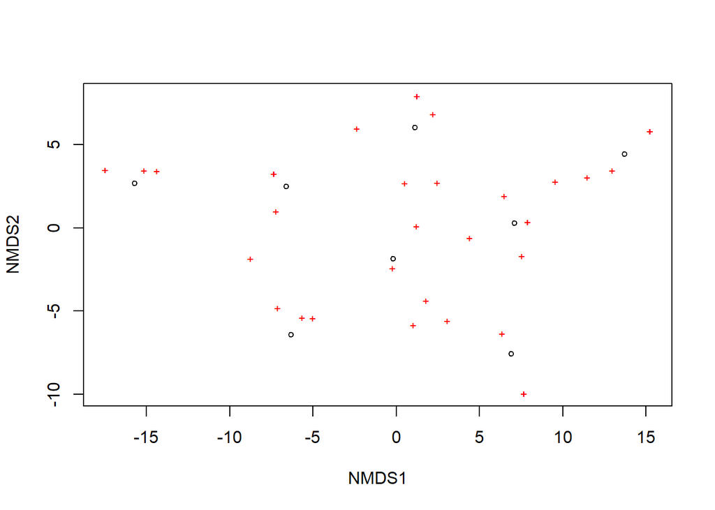

```r
plot(CarnforthNMDS)
```

#As in the other NMDS plots, species are represented by red crosses and communities are #represented by circles.

```r
CarnforthNMDS
```

```
##
## Call:
## metaMDS(comm = CarnforthPS)
##
## global Multidimensional Scaling using monoMDS
##
## Data:     wisconsin(sqrt(CarnforthPS))
## Distance: bray
##
## Dimensions: 2
## Stress:     0.05547398
## Stress type 1, weak ties
## Best solution was repeated 2 times in 20 tries
## The best solution was from try 19 (random start)
## Scaling: centring, PC rotation, halfchange scaling
## Species: expanded scores based on 'wisconsin(sqrt(CarnforthPS))'
```

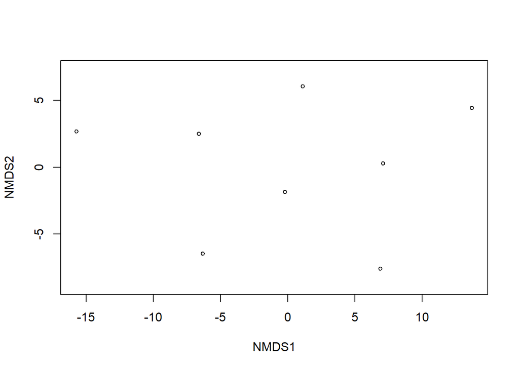

```r
plot(CarnforthNMDS, "sites")   # Produces distance
```

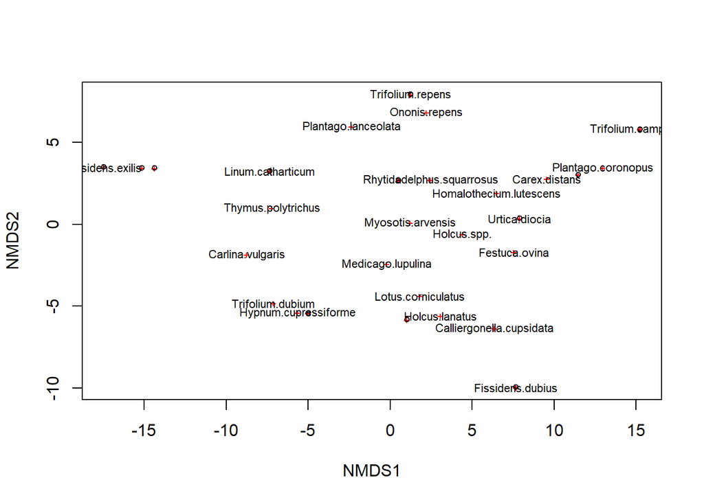

```r
plot(CarnforthNMDS, "species")
orditorp(CarnforthNMDS, "species")
```

#What is interesting about this NMDS is that most of the species are separated out, with #very little clustering or ‘clumping’. This contrasts greatly with the NMDS plots #for Fallin Bing, Addiewell Bing and South Bank Wood (Penicuik). It might still be #useful to look at a CCA for Carnforth as well…

```r
CarnforthCCA <- cca(CarnforthPS, CarnforthPC)
print(CarnforthCCA)
```

```
## Call: cca(X = CarnforthPS, Y = CarnforthPC)
##
##               Inertia Proportion Rank
## Total           3.868      1.000
## Constrained     3.868      1.000    7
## Unconstrained   0.000      0.000    0
## Inertia is scaled Chi-square
## Some constraints or conditions were aliased because they were redundant
## 102 species (variables) deleted due to missingness
##
## Eigenvalues for constrained axes:
##   CCA1   CCA2   CCA3   CCA4   CCA5   CCA6   CCA7
## 0.8089 0.6910 0.6454 0.5739 0.4932 0.4219 0.2338
```

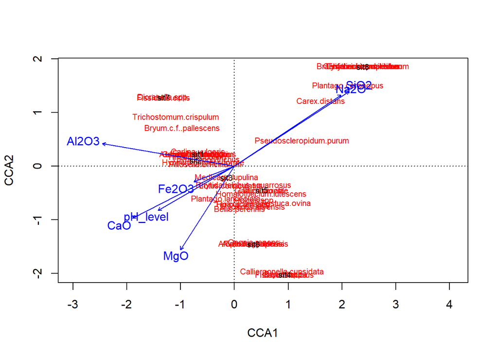

```r
plot(CarnforthCCA)
```

```r
CarnforthCCA1 <- cca(CarnforthPS ~ Na2O + Co + SrO + Al2O3 + Calcite,
                     data = CarnforthPC)

print(CarnforthCCA1)
```

```
## Call: cca(formula = CarnforthPS ~ Na2O + Co + SrO + Al2O3 + Calcite,
## data = CarnforthPC)
##
##               Inertia Proportion Rank
## Total          3.8682     1.0000
## Constrained    3.0308     0.7835    5
## Unconstrained  0.8374     0.2165    2
## Inertia is scaled Chi-square
## 102 species (variables) deleted due to missingness
##
## Eigenvalues for constrained axes:
##   CCA1   CCA2   CCA3   CCA4   CCA5
## 0.7958 0.6891 0.6261 0.5340 0.3858
##
## Eigenvalues for unconstrained axes:
##    CA1    CA2
## 0.5070 0.3303
```

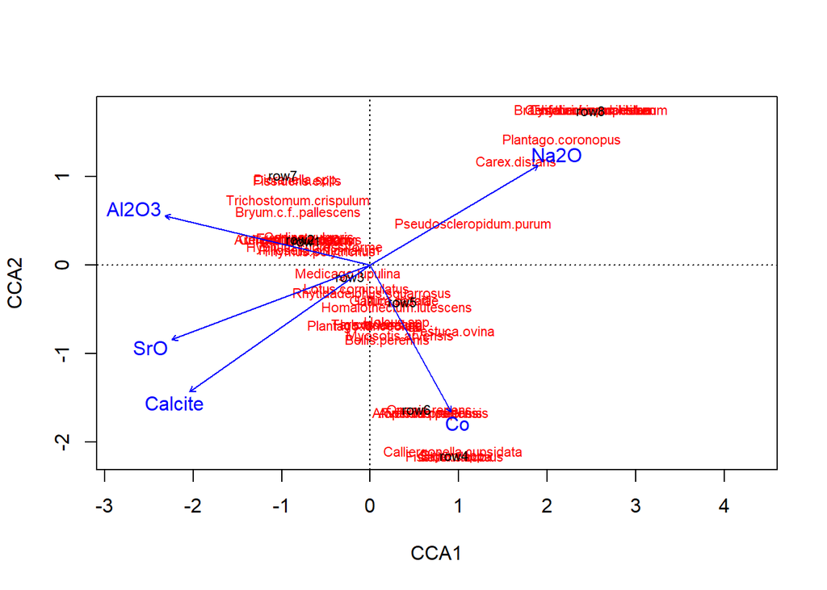

```r
plot(CarnforthCCA1)
```